# Eye–Voice Span in Rapid Automatized Naming: Pan et al. (2013)

Authors

Reinhold Kliegl

Jinger Pan

Published

2026-08-28

After working through this page you will be able to:

- reproduce a covariate-based LMM analysis (`gaze duration` and `eye–voice span` as predictors of psychometric RAN) from a published study;
- complexify a fixed-effect structure with continuous-by-categorical interactions and prune it with likelihood-ratio tests;
- visualize higher-order interactions three ways — with *partial effects* (`MixedModelsExtras.partial_fitted`, the Julia analogue of R’s `remef()`), with *marginal effects* (`Effects.jl`), and with model diagnostics (`MixedModelsMakie.jl`).

**NoteBefore you start**

**Prerequisites:** Analysis of the sleepstudy data for the modeling vocabulary; Transformations and Effects for `Effects.jl`; Creating multi-panel plots for the plotting stack.

**Data used:** `pylsk13.rda`, distributed alongside this page (`examples/eyevoicespan/`). The original R script (`pylsk13_v4.R`) and the paper (`Pan_etal.DevSci.2013.pdf`) are in the same folder.

# 1 Background

Pan et al. (2013) measured the eye movements of Chinese dyslexic and control children during *rapid automatized naming* (RAN) of **digits** (alphanumeric) and **dice** surfaces (symbolic). Both stimulus types require identical oral responses, which controls for effects associated with speech production.

The question addressed on this page is a psychometric one: how well do two eye-movement measures obtained from the computerized RAN task — **gaze duration** (`gaze`, the summed fixation time on an item) and the **eye–voice span** (`evs`, the distance in characters between the currently fixated item and the item currently being named) — predict naming speed (`ran`, seconds to name a card of items), and does that prediction differ between the two `Condition`s (digit/dice) and the two `Group`s (control/dyslexic)?

The analysis follows `pylsk13_v4.R`:

1. **Setup** — read the data, check whether the response needs a transformation, center the covariates.
2. **Model building** — start from an additive covariate model, add the `Condition × Group` interaction, then the full `Condition × Group × evs × gaze` factorial, and prune it back with likelihood-ratio tests.
3. **Visualization** — partial-effect plots (Figures 1 and 2 of the paper), marginal-effect plots, and residual diagnostics.

# 2 Packages

```julia
using AlgebraOfGraphics
using AlgebraOfGraphics: density, linear
using BoxCox
using CairoMakie
using CategoricalArrays
using DataFrames
using Effects
using MixedModels
using MixedModelsMakie
using MixedModelsExtras          # partial_fitted(): the Julia analogue of remef()
using RData                      # to read the .rda file
using Statistics
using StatsBase

using SMLP2026: fit_or_restore

const progress = false
set_aog_theme!()
```

# 3 Read and prepare the data

`pylsk13.rda` contains a single data frame `dat` with one row per child × condition (56 children × 2 conditions = 112 rows).

```julia
dat = DataFrame(load(joinpath(@__DIR__, "pylsk13.rda"))["dat"])
```

112×8 DataFrame

87 rows omitted

| Row | subj Int32 | group Int32 | condition Int32 | ran Float64 | gaze Int32 | evs Float64 | accuracy Int32 | fluency Int32 |
| --- | --- | --- | --- | --- | --- | --- | --- | --- |
| 1 | 101 | 1 | 1 | 13.79 | 242 | 1.33 | 130 | 1192 |
| 2 | 101 | 1 | 2 | 19.61 | 397 | 0.97 | 130 | 1192 |
| 3 | 102 | 1 | 1 | 13.28 | 318 | 0.84 | 119 | 1696 |
| 4 | 102 | 1 | 2 | 17.43 | 372 | 1.06 | 119 | 1696 |
| 5 | 103 | 1 | 1 | 22.66 | 403 | 0.83 | 132 | 1233 |
| 6 | 103 | 1 | 2 | 27.47 | 487 | 0.8 | 132 | 1233 |
| 7 | 104 | 1 | 1 | 13.85 | 295 | 1.28 | 127 | 1124 |
| 8 | 104 | 1 | 2 | 25.05 | 442 | 0.95 | 127 | 1124 |
| 9 | 105 | 1 | 1 | 12.75 | 281 | 1.15 | 103 | 922 |
| 10 | 105 | 1 | 2 | 26.17 | 412 | 0.89 | 103 | 922 |
| 11 | 107 | 1 | 1 | 16.36 | 303 | 1.13 | 124 | 1140 |
| 12 | 107 | 1 | 2 | 28.14 | 441 | 0.87 | 124 | 1140 |
| 13 | 108 | 1 | 1 | 15.33 | 323 | 1.25 | 139 | 1005 |
| ⋮ | ⋮ | ⋮ | ⋮ | ⋮ | ⋮ | ⋮ | ⋮ | ⋮ |
| 101 | 231 | 2 | 1 | 16.21 | 371 | 1.05 | 83 | 317 |
| 102 | 231 | 2 | 2 | 30.27 | 511 | 0.75 | 83 | 317 |
| 103 | 232 | 2 | 1 | 24.96 | 312 | 1.15 | 75 | 344 |
| 104 | 232 | 2 | 2 | 28.24 | 411 | 1.05 | 75 | 344 |
| 105 | 233 | 2 | 1 | 22.55 | 420 | 0.18 | 92 | 583 |
| 106 | 233 | 2 | 2 | 24.79 | 528 | 0.67 | 92 | 583 |
| 107 | 234 | 2 | 1 | 25.52 | 435 | 0.73 | 90 | 610 |
| 108 | 234 | 2 | 2 | 29.59 | 557 | 0.77 | 90 | 610 |
| 109 | 235 | 2 | 1 | 17.39 | 382 | 0.84 | 93 | 527 |
| 110 | 235 | 2 | 2 | 28.1 | 520 | 0.68 | 93 | 527 |
| 111 | 236 | 2 | 1 | 19.48 | 326 | 0.97 | 94 | 752 |
| 112 | 236 | 2 | 2 | 28.89 | 495 | 0.54 | 94 | 752 |

We follow the general recommendation to code the levels of grouping variables as strings (here `S101`, `S102`, …), to give factors meaningful level names, and to fix a sensible level order. `ran` is log-transformed (justified below) and the two covariates are **centered** (not scaled) so that the intercept and the lower-order terms are interpretable at the average `gaze` and `evs`.

```julia
transform!(dat,
  :subj => (x -> categorical(string.("S", x))) => :Subj,
  :group => (x -> categorical(recode(x, 1 => "control", 2 => "dyslexic"))) => :Group,
  :condition => (x -> categorical(recode(x, 1 => "digit", 2 => "dice"))) => :Condition,
  :ran => ByRow(log) => :lran,
)
levels!(dat.Group, ["control", "dyslexic"])
levels!(dat.Condition, ["digit", "dice"])
dat.evs_c = dat.evs .- mean(dat.evs)
dat.gaze_c = dat.gaze .- mean(dat.gaze)
describe(dat)
```

14×7 DataFrame

| Row | variable Symbol | mean Union… | min Any | median Union… | max Any | nmissing Int64 | eltype DataType |
| --- | --- | --- | --- | --- | --- | --- | --- |
| 1 | subj | 171.696 | 101 | 202.5 | 236 | 0 | Int32 |
| 2 | group | 1.53571 | 1 | 2.0 | 2 | 0 | Int32 |
| 3 | condition | 1.5 | 1 | 1.5 | 2 | 0 | Int32 |
| 4 | ran | 21.9127 | 10.06 | 22.58 | 42.42 | 0 | Float64 |
| 5 | gaze | 402.429 | 242 | 406.0 | 557 | 0 | Int32 |
| 6 | evs | 0.871607 | 0.18 | 0.84 | 1.73 | 0 | Float64 |
| 7 | accuracy | 104.554 | 55 | 94.0 | 141 | 0 | Int32 |
| 8 | fluency | 782.429 | 253 | 730.0 | 1696 | 0 | Int32 |
| 9 | Subj |  | S101 |  | S236 | 0 | CategoricalValue{String, UInt32} |
| 10 | Group |  | control |  | dyslexic | 0 | CategoricalValue{String, UInt32} |
| 11 | Condition |  | digit |  | dice | 0 | CategoricalValue{String, UInt32} |
| 12 | lran | 3.04789 | 2.30857 | 3.11706 | 3.74762 | 0 | Float64 |
| 13 | evs_c | -2.83503e-16 | -0.691607 | -0.0316071 | 0.858393 | 0 | Float64 |
| 14 | gaze_c | -1.82711e-14 | -160.429 | 3.57143 | 154.571 | 0 | Float64 |

## 3.1 Does the response need a transformation?

The R script uses `MASS::boxcox()` to justify a log transform of `ran` (but not of `gaze` or `evs`). The Julia equivalent fits a `BoxCoxTransformation` to a mixed model of the untransformed response.

```julia
m_ran = fit(MixedModel,
  @formula(ran ~ 1 + Condition * Group + evs_c + gaze_c + (1 | Subj)),
  dat;
  contrasts=Dict(:Condition => DummyCoding(; base="digit"),
                 :Group => DummyCoding(; base="control")),
  progress,
)
bc = fit(BoxCoxTransformation, m_ran; progress)
```

```
Box-Cox transformation

estimated λ: 0.3804
resultant transformation:

 y^0.4 - 1
-----------
    0.4
```

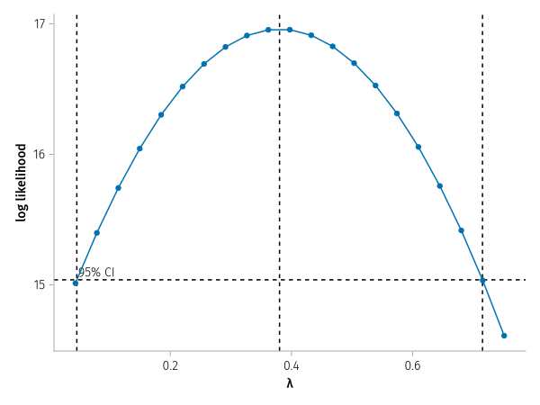

```julia
boxcoxplot(bc; conf_level=0.95)
```

## 3.2 Condition and Group means

```julia
cell_means = combine(
  groupby(dat, [:Group, :Condition]),
  :lran => mean => :lran_m,
  :lran => (x -> std(x) / sqrt(length(x))) => :lran_se,
  :evs => mean => :evs_m,
  :gaze => mean => :gaze_m,
  nrow => :n,
)
cell_means
```

4×7 DataFrame

| Row | Group Cat… | Condition Cat… | lran_m Float64 | lran_se Float64 | evs_m Float64 | gaze_m Float64 | n Int64 |
| --- | --- | --- | --- | --- | --- | --- | --- |
| 1 | control | digit | 2.66863 | 0.0375581 | 1.09731 | 317.346 | 26 |
| 2 | control | dice | 3.15163 | 0.0304036 | 0.876923 | 426.038 | 26 |
| 3 | dyslexic | digit | 3.02093 | 0.0317818 | 0.810333 | 385.9 | 30 |
| 4 | dyslexic | dice | 3.31362 | 0.0266264 | 0.732667 | 472.233 | 30 |

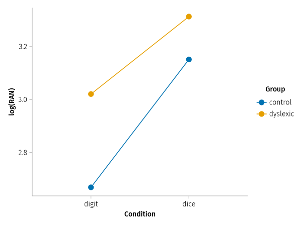

Figure 2: Mean log(RAN) by Condition and Group. Naming dice is slower than naming digits in both groups, and the group difference is larger for digits.

```julia
draw(
  data(cell_means) *
  mapping(:Condition, :lran_m => "log(RAN)"; color=:Group, group=:Group) *
  visual(ScatterLines; markersize=16),
)
```

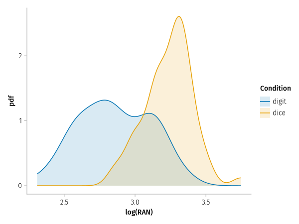

Figure 3: Comparative density of log(RAN) by Condition.

```julia
draw(
  data(dat) *
  mapping(:lran => "log(RAN)"; color=:Condition) *
  density(),
)
```

# 4 Linear mixed models

The two categorical predictors use treatment (dummy) contrasts with the same reference levels as the published analysis (`digit` and `control`), so the coefficients reproduce Table 3 of Pan et al. (2013).

**Tip**

If the *intercept* should estimate the grand mean rather than the `digit`/`control` cell — usually preferable in factorial designs — swap `DummyCoding` for `EffectsCoding`. The omnibus tests below are unchanged; only the meaning of the lower-order coefficients changes.

```julia
contrasts = Dict(
  :Condition => DummyCoding(; base="digit"),
  :Group => DummyCoding(; base="control"),
)
```

```
Dict{Symbol, DummyCoding} with 2 entries:
  :Group     => DummyCoding("control", nothing)
  :Condition => DummyCoding("digit", nothing)
```

All models keep the maximal grouping structure supported by this design: a single by-child random intercept (`(1 | Subj)`). With only two observations per child there is no room for by-child random slopes.

## 4.1 Model building

```julia
m00 = fit_or_restore("eyevoicespan_m00.json", MixedModel,
  @formula(lran ~ 1 + Condition + Group + evs_c + gaze_c + (1 | Subj)),
  dat; contrasts, progress)
```

|  | Est. | SE | z | p | σ_Subj |
| --- | --- | --- | --- | --- | --- |
| (Intercept) | 2.8926 | 0.0354 | 81.80 | <1e-99 | 0.0857 |
| Condition: dice | 0.1861 | 0.0378 | 4.92 | <1e-06 |  |
| Group: dyslexic | 0.1163 | 0.0362 | 3.22 | 0.0013 |  |
| evs_c | -0.1934 | 0.0713 | -2.71 | 0.0067 |  |
| gaze_c | 0.0017 | 0.0004 | 4.69 | <1e-05 |  |
| Residual | 0.1091 |  |  |  |  |

```julia
m05 = fit_or_restore("eyevoicespan_m05.json", MixedModel,
  @formula(lran ~ 1 + Condition * Group + evs_c + gaze_c + (1 | Subj)),
  dat; contrasts, progress)
```

|  | Est. | SE | z | p | σ_Subj |
| --- | --- | --- | --- | --- | --- |
| (Intercept) | 2.8436 | 0.0374 | 76.04 | <1e-99 | 0.0903 |
| Condition: dice | 0.2710 | 0.0438 | 6.19 | <1e-09 |  |
| Group: dyslexic | 0.1936 | 0.0427 | 4.53 | <1e-05 |  |
| evs_c | -0.1688 | 0.0696 | -2.43 | 0.0153 |  |
| gaze_c | 0.0016 | 0.0004 | 4.54 | <1e-05 |  |
| Condition: dice & Group: dyslexic | -0.1303 | 0.0390 | -3.34 | 0.0008 |  |
| Residual | 0.1000 |  |  |  |  |

```julia
m10 = fit_or_restore("eyevoicespan_m10.json", MixedModel,
  @formula(lran ~ 1 + Condition * Group * evs_c * gaze_c + (1 | Subj)),
  dat; contrasts, progress)
```

|  | Est. | SE | z | p | σ_Subj |
| --- | --- | --- | --- | --- | --- |
| (Intercept) | 3.0252 | 0.0788 | 38.39 | <1e-99 | 0.0948 |
| Condition: dice | 0.0758 | 0.0867 | 0.87 | 0.3817 |  |
| Group: dyslexic | -0.0243 | 0.0848 | -0.29 | 0.7747 |  |
| evs_c | -0.8446 | 0.2443 | -3.46 | 0.0005 |  |
| gaze_c | 0.0040 | 0.0011 | 3.73 | 0.0002 |  |
| Condition: dice & Group: dyslexic | 0.1388 | 0.1001 | 1.39 | 0.1656 |  |
| Condition: dice & evs_c | 0.6823 | 0.2797 | 2.44 | 0.0147 |  |
| Group: dyslexic & evs_c | 0.8354 | 0.2687 | 3.11 | 0.0019 |  |
| Condition: dice & gaze_c | -0.0018 | 0.0011 | -1.66 | 0.0970 |  |
| Group: dyslexic & gaze_c | -0.0024 | 0.0012 | -2.02 | 0.0437 |  |
| evs_c & gaze_c | -0.0075 | 0.0029 | -2.57 | 0.0103 |  |
| Condition: dice & Group: dyslexic & evs_c | -0.6611 | 0.3634 | -1.82 | 0.0689 |  |
| Condition: dice & Group: dyslexic & gaze_c | 0.0008 | 0.0013 | 0.61 | 0.5421 |  |
| Condition: dice & evs_c & gaze_c | 0.0076 | 0.0040 | 1.89 | 0.0588 |  |
| Group: dyslexic & evs_c & gaze_c | 0.0011 | 0.0035 | 0.31 | 0.7556 |  |
| Condition: dice & Group: dyslexic & evs_c & gaze_c | -0.0058 | 0.0050 | -1.17 | 0.2416 |  |
| Residual | 0.0851 |  |  |  |  |

`m10` is the full `Condition × Group × evs × gaze` factorial. The three highest-order terms that involve the `evs × gaze` product are not significant, so we drop them: the `Condition × Group × evs × gaze` four-way, the `Group × evs × gaze` three-way, and the `Condition × evs × gaze` three-way. What remains (`m09`) is the model whose coefficients correspond to Table 3 of Pan et al. (2013). (The `z` statistics here differ slightly from the published `t` values because of software differences — ML vs. REML, contrast parameterization — but the substantive pattern is the same.)

```julia
m09 = fit_or_restore("eyevoicespan_m09.json", MixedModel,
  @formula(lran ~ 1 + Condition + Group + evs_c + gaze_c +
    Condition & Group + Condition & evs_c + Condition & gaze_c +
    Group & evs_c + Group & gaze_c + evs_c & gaze_c +
    Condition & Group & evs_c + Condition & Group & gaze_c +
    (1 | Subj)),
  dat; contrasts, progress)
```

|  | Est. | SE | z | p | σ_Subj |
| --- | --- | --- | --- | --- | --- |
| (Intercept) | 2.9984 | 0.0683 | 43.88 | <1e-99 | 0.0982 |
| Condition: dice | 0.0770 | 0.0760 | 1.01 | 0.3108 |  |
| Group: dyslexic | 0.0117 | 0.0789 | 0.15 | 0.8825 |  |
| evs_c | -0.6308 | 0.1440 | -4.38 | <1e-04 |  |
| gaze_c | 0.0036 | 0.0009 | 4.17 | <1e-04 |  |
| Condition: dice & Group: dyslexic | 0.1299 | 0.0971 | 1.34 | 0.1807 |  |
| Condition: dice & evs_c | 0.6085 | 0.1998 | 3.05 | 0.0023 |  |
| Condition: dice & gaze_c | -0.0013 | 0.0009 | -1.41 | 0.1598 |  |
| Group: dyslexic & evs_c | 0.6163 | 0.1842 | 3.35 | 0.0008 |  |
| Group: dyslexic & gaze_c | -0.0020 | 0.0011 | -1.90 | 0.0569 |  |
| evs_c & gaze_c | -0.0051 | 0.0015 | -3.46 | 0.0006 |  |
| Condition: dice & Group: dyslexic & evs_c | -0.5512 | 0.2010 | -2.74 | 0.0061 |  |
| Condition: dice & Group: dyslexic & gaze_c | 0.0002 | 0.0011 | 0.18 | 0.8570 |  |
| Residual | 0.0861 |  |  |  |  |

```julia
MixedModels.likelihoodratiotest(m00, m05, m09, m10)
```

|  | model-dof | -2 logLik | χ² | χ²-dof | P(>χ²) |
| --- | --- | --- | --- | --- | --- |
| lran ~ 1 + Condition + Group + evs_c + gaze_c + (1 \| Subj) | 7 | 134 |  |  |  |
| lran ~ 1 + Condition + Group + evs_c + gaze_c + Condition & Group + (1 \| Subj) | 8 | 144 | 10 | 1 | 0.0013 |
| lran ~ 1 + Condition + Group + evs_c + gaze_c + Condition & Group + Condition & evs_c + Condition & gaze_c + Group & evs_c + Group & gaze_c + evs_c & gaze_c + Condition & Group & evs_c + Condition & G… | 15 | 160 | 16 | 7 | 0.0258 |
| lran ~ 1 + Condition + Group + evs_c + gaze_c + Condition & Group + Condition & evs_c + Group & evs_c + Condition & gaze_c + Group & gaze_c + evs_c & gaze_c + Condition & Group & evs_c + Condition & G… | 18 | 164 | 4 | 3 | 0.2197 |

Adding `Condition × Group` (`m05`) and the covariate interactions retained in `m09` each improve the fit reliably; the extra terms in `m10` do not. `m09` is the preferred model.

## 4.2 The preferred model

```julia
VarCorr(m09)
```

|  | Column | Variance | Std.Dev |
| --- | --- | --- | --- |
| Subj | (Intercept) | 0.0096367 | 0.0981667 |
| Residual |  | 0.0074142 | 0.0861058 |

```julia
m09
```

|  | Est. | SE | z | p | σ_Subj |
| --- | --- | --- | --- | --- | --- |
| (Intercept) | 2.9984 | 0.0683 | 43.88 | <1e-99 | 0.0982 |
| Condition: dice | 0.0770 | 0.0760 | 1.01 | 0.3108 |  |
| Group: dyslexic | 0.0117 | 0.0789 | 0.15 | 0.8825 |  |
| evs_c | -0.6308 | 0.1440 | -4.38 | <1e-04 |  |
| gaze_c | 0.0036 | 0.0009 | 4.17 | <1e-04 |  |
| Condition: dice & Group: dyslexic | 0.1299 | 0.0971 | 1.34 | 0.1807 |  |
| Condition: dice & evs_c | 0.6085 | 0.1998 | 3.05 | 0.0023 |  |
| Condition: dice & gaze_c | -0.0013 | 0.0009 | -1.41 | 0.1598 |  |
| Group: dyslexic & evs_c | 0.6163 | 0.1842 | 3.35 | 0.0008 |  |
| Group: dyslexic & gaze_c | -0.0020 | 0.0011 | -1.90 | 0.0569 |  |
| evs_c & gaze_c | -0.0051 | 0.0015 | -3.46 | 0.0006 |  |
| Condition: dice & Group: dyslexic & evs_c | -0.5512 | 0.2010 | -2.74 | 0.0061 |  |
| Condition: dice & Group: dyslexic & gaze_c | 0.0002 | 0.0011 | 0.18 | 0.8570 |  |
| Residual | 0.0861 |  |  |  |  |

The coefficients of interest:

- **`evs_c` (−0.63)** — within `digit`/`control`, a larger eye–voice span predicts *faster* (lower log) naming.
- **`Condition: dice & Group: dyslexic & evs_c` (−0.55, *p* ≈ .006)** — the three-way interaction: the EVS benefit is distributed differently across cells (Figure 1 of the paper).
- **`evs_c & gaze_c` (−0.005, *p* ≈ .001)** — the two covariates interact.
- **`gaze_c` (+0.0036)** — longer gaze durations predict *slower* naming, as expected.

# 5 Diagnostics

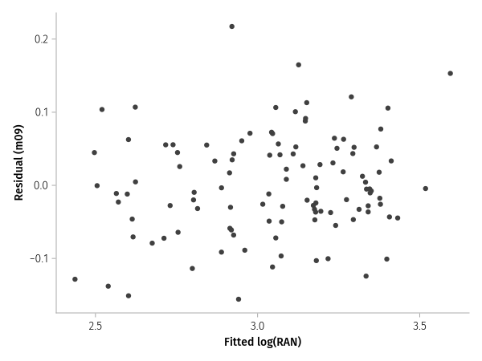

Figure 4: Residuals vs. fitted values for m09.

```julia
draw(
  data((; f=fitted(m09), r=residuals(m09))) *
  mapping(:f => "Fitted log(RAN)", :r => "Residual (m09)") *
  visual(Scatter),
)
```

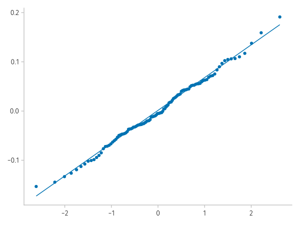

Figure 5: Normal quantile plot of the m09 residuals.

```julia
qqnorm(residuals(m09); qqline=:fitrobust)
```

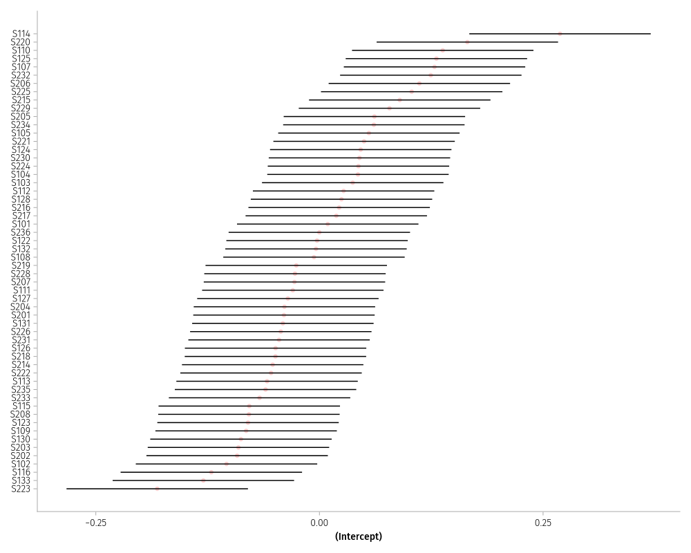

Figure 6: Prediction intervals on the by-child random intercepts (m09).

```julia
caterpillar(m09, :Subj)
```

# 6 Partial-effect plots (the `remef()` analogue)

The R script visualizes the higher-order interactions with **partial effects** computed by `remef()`: it takes the observed response, removes the contribution of the nuisance terms (here everything involving `gaze` and the random intercept), and keeps the terms of interest plus the residual. The result is an “adjusted” response that isolates one slice of the model.

`MixedModelsExtras.partial_fitted` is the Julia counterpart. It returns the fitted values for a chosen set of coefficients; adding the residuals back reproduces `remef(..., keep=TRUE)`.

```julia
# keep every fixed effect that does NOT involve gaze; drop the by-child intercept
keep_evs = filter(c -> !occursin("gaze_c", c), coefnames(m09))
# keep every fixed effect that does NOT involve evs; drop the by-child intercept
keep_gaze = filter(c -> !occursin("evs_c", c), coefnames(m09))

dp = select(dat, :Subj, :Group, :Condition, :evs, :gaze, :lran)
dp.partial_evs =
  partial_fitted(m09, keep_evs, Dict(:Subj => String[]); mode=:include) .+ residuals(m09)
dp.partial_gaze =
  partial_fitted(m09, keep_gaze, Dict(:Subj => String[]); mode=:include) .+ residuals(m09)
dp.cg = categorical(string.(dp.Condition, " / ", dp.Group))
first(dp, 6)
```

6×9 DataFrame

| Row | Subj Cat… | Group Cat… | Condition Cat… | evs Float64 | gaze Int32 | lran Float64 | partial_evs Float64 | partial_gaze Float64 | cg Cat… |
| --- | --- | --- | --- | --- | --- | --- | --- | --- | --- |
| 1 | S101 | control | digit | 1.33 | 242 | 2.62394 | 2.81295 | 2.52721 | digit / control |
| 2 | S101 | control | dice | 0.97 | 397 | 2.97604 | 2.97662 | 2.96624 | dice / control |
| 3 | S102 | control | digit | 0.84 | 318 | 2.58626 | 3.00638 | 2.68389 | digit / control |
| 4 | S102 | control | dice | 1.06 | 372 | 2.85819 | 3.00322 | 2.93693 | dice / control |
| 5 | S103 | control | digit | 0.83 | 403 | 3.1206 | 3.08125 | 3.05705 | digit / control |
| 6 | S103 | control | dice | 0.8 | 487 | 3.31309 | 3.049 | 3.2433 | dice / control |

For plotting we stack the observed response and each partial response into long form, so that “observed vs. adjusted” becomes a facet column with a single shared legend.

```julia
stack_partial(col, label) =
  insertcols!(select(dp, :evs, :gaze, :cg, col => :y), :kind => label)

dp_evs = vcat(stack_partial(:lran, "observed"), stack_partial(:partial_evs, "adjusted"))
dp_gaze = vcat(stack_partial(:lran, "observed"), stack_partial(:partial_gaze, "adjusted"))
first(dp_evs, 4)
```

4×5 DataFrame

| Row | evs Float64 | gaze Int32 | cg Cat… | y Float64 | kind String |
| --- | --- | --- | --- | --- | --- |
| 1 | 1.33 | 242 | digit / control | 2.62394 | observed |
| 2 | 0.97 | 397 | dice / control | 2.97604 | observed |
| 3 | 0.84 | 318 | digit / control | 2.58626 | observed |
| 4 | 1.06 | 372 | dice / control | 2.85819 | observed |

**NoteHow the specification maps onto R’s remef()**

`remef(m09, fix = c(1, "condition:group:evs_c"), keep = TRUE, grouping = TRUE, ran = NULL)` keeps the intercept, the three-way `condition:group:evs_c` term, **and** (because `grouping = TRUE`) every lower-order term built from `condition`, `group`, and `evs_c`; it removes everything involving `gaze_c` and all random effects. `filter(c -> !occursin("gaze_c", c), coefnames(m09))` selects exactly that set of fixed-effect coefficients, and `Dict(:Subj => String[])` drops the random intercept.

## 6.1 Figure 1 — `Condition × Group × EVS`

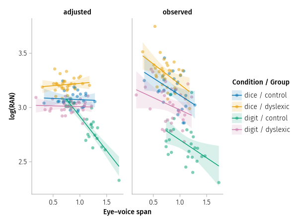

```julia
draw(
  data(dp_evs) *
  mapping(
    :evs => "Eye–voice span",
    :y => "log(RAN)";
    color=:cg => "Condition / Group",
    col=:kind,
  ) *
  (visual(Scatter; alpha=0.5) + linear());
  facet=(; linkyaxes=:all),
)
```

The partial plot sharpens the pattern noted in the paper: the EVS benefit (negative slope) is present for `digit` naming in the control group but is weak or absent in the `dice / dyslexic` cell.

## 6.2 Figure 2 — `Condition × Group × Gaze`

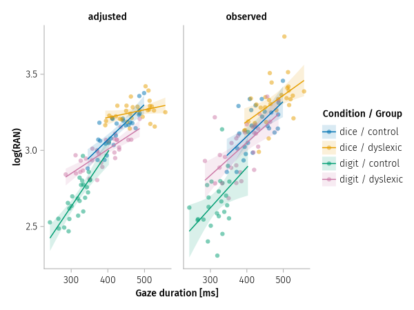

```julia
draw(
  data(dp_gaze) *
  mapping(
    :gaze => "Gaze duration [ms]",
    :y => "log(RAN)";
    color=:cg => "Condition / Group",
    col=:kind,
  ) *
  (visual(Scatter; alpha=0.5) + linear());
  facet=(; linkyaxes=:all),
)
```

# 7 Marginal-effect plots with `Effects.jl`

`partial_fitted` adjusts *observed* data points. `Effects.jl` instead evaluates the *model’s prediction* on a regular grid, holding the variables that are not on the grid at a typical value (the mean; for the centered covariates that is `0`). This is the Julia analogue of R’s `effects` / `emmeans`.

## 7.1 EVS effect by Condition and Group

```julia
evsgrid = Dict(
  :evs_c => range(extrema(dat.evs_c)...; length=50),
  :Condition => levels(dat.Condition),
  :Group => levels(dat.Group),
)
eff_evs = effects(evsgrid, m09)
eff_evs.evs = eff_evs.evs_c .+ mean(dat.evs)
eff_evs.cg = categorical(string.(eff_evs.Condition, " / ", eff_evs.Group))
first(eff_evs, 6)
```

6×9 DataFrame

| Row | evs_c Float64 | Group Cat… | Condition Cat… | lran Float64 | err Float64 | lower Float64 | upper Float64 | evs Float64 | cg Cat… |
| --- | --- | --- | --- | --- | --- | --- | --- | --- | --- |
| 1 | -0.691607 | control | digit | 3.43466 | 0.134987 | 3.29967 | 3.56965 | 0.18 | digit / control |
| 2 | -0.659974 | control | digit | 3.4147 | 0.131029 | 3.28368 | 3.54573 | 0.211633 | digit / control |
| 3 | -0.628342 | control | digit | 3.39475 | 0.12711 | 3.26764 | 3.52186 | 0.243265 | digit / control |
| 4 | -0.596709 | control | digit | 3.3748 | 0.123235 | 3.25156 | 3.49803 | 0.274898 | digit / control |
| 5 | -0.565077 | control | digit | 3.35484 | 0.119408 | 3.23543 | 3.47425 | 0.306531 | digit / control |
| 6 | -0.533444 | control | digit | 3.33489 | 0.115635 | 3.21925 | 3.45052 | 0.338163 | digit / control |

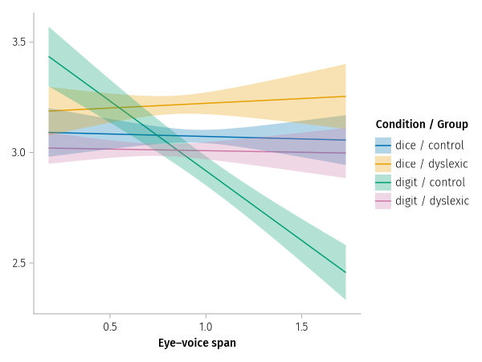

Figure 9: Model-predicted log(RAN) as a function of eye–voice span, with 95% confidence bands, by Condition and Group.

```julia
draw(
  data(eff_evs) *
  mapping(
    :evs => "Eye–voice span",
    color=:cg => "Condition / Group",
  ) * (
    mapping(:lran => "log(RAN)") * visual(Lines) +
    mapping(:lower, :upper) * visual(Band; alpha=0.3)
    )
  )
```

## 7.2 Gaze effect by Condition and Group

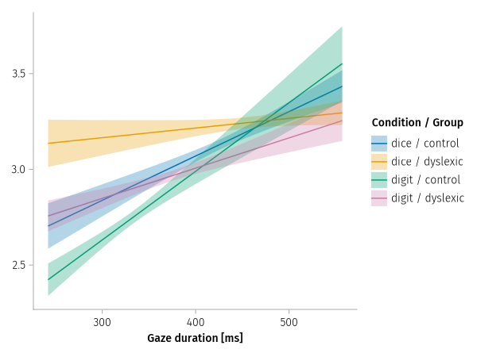

Figure 10: Model-predicted log(RAN) as a function of gaze duration, with 95% confidence bands, by Condition and Group.

```julia
let
  gazegrid = Dict(
    :gaze_c => range(extrema(dat.gaze_c)...; length=50),
    :Condition => levels(dat.Condition),
    :Group => levels(dat.Group),
  )
  eff_gaze = effects(gazegrid, m09)
  eff_gaze.gaze = eff_gaze.gaze_c .+ mean(dat.gaze)
  eff_gaze.cg = categorical(string.(eff_gaze.Condition, " / ", eff_gaze.Group))
  draw(
    data(eff_gaze) *
    mapping(:gaze => "Gaze duration [ms]"; color=:cg => "Condition / Group") * (
      mapping(:lran => "log(RAN)") * visual(Lines) +
      mapping(:lower, :upper) * visual(Band; alpha=0.3)
  ))
end
```

## 7.3 `evs × gaze` interaction

The reliable `evs_c & gaze_c` term means the gaze slope changes with EVS. We show it by evaluating the model at three EVS levels (roughly the tertiles).

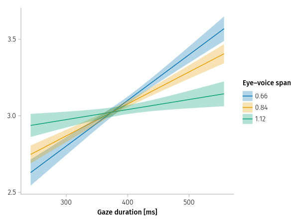

Figure 11: The gaze-duration effect at small, medium, and large eye–voice span (model prediction, 95% bands).

```julia
let
  qs = quantile(dat.evs, [1/6, 1/2, 5/6])
  grid = Dict(
    :gaze_c => range(extrema(dat.gaze_c)...; length=50),
    :evs_c => qs .- mean(dat.evs),
  )
  eff = effects(grid, m09)
  eff.gaze = eff.gaze_c .+ mean(dat.gaze)
  eff.evs_level = categorical(
    round.(eff.evs_c .+ mean(dat.evs); digits=2);
  )
  draw(
    data(eff) *
    mapping(:gaze => "Gaze duration [ms]";
            color=:evs_level => "Eye–voice span") *
    (mapping(:lran => "log(RAN)") * visual(Lines) +
     mapping(:lower, :upper) * visual(Band; alpha=0.3))
  )
end
```

# 8 See also

- Transformations and Effects — the `Effects.jl` workflow and Box–Cox transformations in more detail.
- The Emotikon Project — model complexification and PCA of the random effects on a large dataset.
- R’s [`remef`](https://github.com/hohenstein/remef) and the `partial_fitted` docstring in `MixedModelsExtras`.

# 9 References

Pan, J., Yan, M., Laubrock, J., Shu, H., & Kliegl, R. (2013). Eye–voice span during rapid automatized naming of digits and dice in Chinese normal and dyslexic children. *Developmental Science*, *16*(6), 967–979. https://doi.org/10.1111/desc.12075

## 9.1 Exercises

1. **Contrast coding.** Refit `m09` with `EffectsCoding` for `Condition` and `Group`. Which coefficients change, which stay the same, and what does the intercept estimate now?

**NoteSolution**

The omnibus likelihood-ratio tests, `VarCorr`, the residual standard deviation, and the fitted values are all unchanged — the model space is the same. The intercept now estimates the grand mean (the unweighted average over the four `Condition × Group` cells) instead of the `digit`/`control` cell, and every lower-order `Condition`/`Group` coefficient becomes a deviation from that grand mean rather than a simple difference from a reference level. The highest-order interaction coefficient is unchanged up to a scale factor.

2. **Partial vs. marginal.** Figure 7 (partial effects) and Figure 9 (marginal effects) both show the EVS slopes by cell. What does each one add that the other does not?

**NoteSolution**

The partial-effect plot keeps the residuals, so it shows the *scatter* of individual observations around the adjusted regression line — useful for spotting influential points and for judging how much of the variance the term actually explains. The marginal-effect plot shows the model’s prediction with a proper confidence band and no leftover noise from other terms, which makes the *estimated* slopes and their uncertainty directly comparable across cells. Use partial effects to inspect the data given the model; use marginal effects to communicate the model.

3. **Why center?** The covariates were centered before fitting. What would change in the `m09` coefficient table if `evs` and `gaze` entered on their raw scales, and would any of the omnibus tests change?

**NoteSolution**

Only the interpretation of the lower-order terms shifts. With raw covariates, `Condition: dice` would estimate the digit-vs-dice difference at `evs = 0` and `gaze = 0` — an extrapolation far outside the data — inflating its standard error and making it hard to interpret. The intercept would likewise refer to `evs = gaze = 0`. The higher-order interaction coefficients, the variance components, the fitted values, and every likelihood-ratio test are invariant to centering.

*This page was rendered from git revision [29e8d33](https://github.com/RePsychLing/SMLP2026/tree/29e8d33  
) using Quarto 1.10.18 and Julia 1.12.7.*

Back to top